En este primer apartado se presenta el análisis exploratorio de los datos del reto Microsoft Predictive Modelling de Cajamar.

**Introducción Cajamar**

Cajamar es una entidad financiera resultante de la fusión de diversas cajas rurales españolas. Sus primeras oficinas abrireron sus puertas en 1966 en Almería. En 1988 iniciaron su expansión integrando otras cajas rurales y cooperativas, actividad que siguieron desarrolando a lo largo de los siguientes años, especialmente a partir de los años 2000. Actualmente tiene más de 1,4 millones de socios y 4 millones clientes.

Las actividades de Cajamar Caja Rural atienden las necesidades y demandas de financiación, ahorro e inversión de sus socios y clientes. Realiza toda clase de operaciones activas, pasivas y de servicios, entre ellas las de banca al por menor en su red de sucursales, banca corporativa, financiación hipotecaria, banca telefónica y banca electrónica, operaciones financieras con no residentes, gestión de fondos y patrimonios, arrendamiento financiero, seguros y otros productos secundarios para captación de recursos o financiación a clientes.

**Primeros pasos**

```r
# Librerias usadas
suppressPackageStartupMessages({
library('ggplot2')
library('zoo')
library('caret')
library('data.table')
library('lubridate')
library('Hmisc')
})

# Cargar datos
data.train <- as.data.table(read.table('/Users/random6/data/train2.txt',header = T, sep = "|", stringsAsFactors = F))

data.test<- as.data.table(read.table('/Users/random6/data/test2.txt',header = T, sep = '|', stringsAsFactors = F))
```

Primero se evaluan las dimensiones de los datasets y se hacen comprovaciones senzillas:

```r
##dimensiones
#data train
nrow(data.train)
ncol(data.train)
#data set
nrow(data.test)
ncol(data.test)

##hay entradas duplicadas?
anyDuplicated(data.train)
anyDuplicated(data.test)

##hay missing values?
sapply(data.train,function(x)any(is.na(x)))
sapply(data.test,function(x)any(is.na(x)))
```

El dataset train original tiene una dimensión de 3350601 entradas por 8 variables y el dataset test, 1147687 entradas y 8 variables. Antes de empezar se tienen que comprobar si hay entradas duplicadas y/o missing values. En este caso no hay duplicados ni missing values.

** Variables ** Primero de todo, vamos a explorar las variables:

```r
str(data.train)
```

El significado de las variables es el siguiente:

“ID_Customer” = Identificador de cliente  
“Cod_Prod” = Código de la modalidad de producto contratado  
“Cod_Fecha” = Fecha de contratación de la modalidad de producto  
“Socio_Demo_01” = Edad “Socio_Demo_02” = Antigüedad “Socio_Demo_03” = Ingresos “Socio_Demo_04” = Sexo (1: Hombre, 2: Mujer) “Socio_Demo_05” = Segmento (00: Particular | 01:Agricultor | 02:Comercio | 03:Autónomo)

Así pues, tenemos el identificador del usuario, el codigo del producto comprado, la fecha de la compra y características demográficas del usuario.

*Visualización variables sociodemográficas*

Para evaluar las variables sociodemográficas de manera dinámica se ha preparado un Desktop con Power BI de Microsoft. De esta manera se pueden visualizar diferentes gráficos dinámicos de estas variables.

[CajamarPowerBI](https://app.powerbi.com/view?r=eyJrIjoiN2I5MzM5MTUtZWZhMi00MmNlLWI0NmEtMjEwOTY1NWMzOTZjIiwidCI6ImEyMzEzY2FiLWIxYzMtNGYzYS1iYjExLTIxNTc0NDdkZGJiNCIsImMiOjh9)

*Obtener información con la fecha de compra* Nos interesa tener la información de la fecha de compra también separada en mes y año, ya que pueden haber productos que se compren en algunas épocas del año determinadas. Hacemos el cambio.

```r
##data.train
#variable año
data.train[,year := unlist(strsplit(data.train[,Cod_Fecha],'-'))[seq(1,length(unlist(strsplit(data.train[,Cod_Fecha],'-'))),2)]]
#variable mes
data.train[,month := unlist(strsplit(data.train[,Cod_Fecha],'-'))[seq(2,length(unlist(strsplit(data.train[,Cod_Fecha],'-'))),2)]]
#variable date en formato fecha
data.train[,date:=as.Date(as.yearmon(Cod_Fecha))]

##data.test
#variable año
data.test[,year := unlist(strsplit(data.test[,Cod_Fecha],'-'))[seq(1,length(unlist(strsplit(data.test[,Cod_Fecha],'-'))),2)]]
#variable mes
data.test[,month := unlist(strsplit(data.test[,Cod_Fecha],'-'))[seq(2,length(unlist(strsplit(data.test[,Cod_Fecha],'-'))),2)]]
#variable date en formato fecha
data.test[,date:=as.Date(as.yearmon(Cod_Fecha))]
```

Una comprovación importante es saber si el dataset de test tiene una distribución de año de compras similar al dataset de train. Vamos a mirarlo.

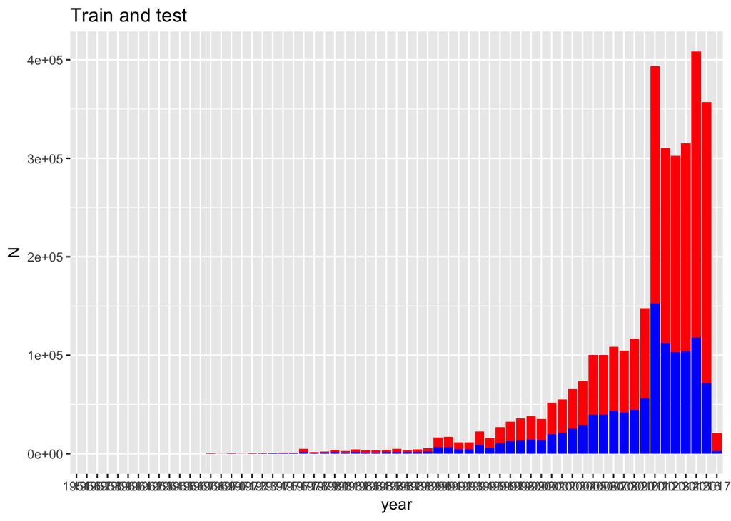

```r
ggplot(data.train[,.N,by=year], aes(x = year, y = N)) + geom_bar(stat = 'identity', fill = 'red') + geom_bar(data = data.test[,.N,by = year], aes(x = year, y = N), fill = 'blue', stat = 'identity') + ggtitle('Train and test')
```

Podemos ver que los años de compra se distribuyen de manera muy parecida en los dos datasets. Es interesante observar que tenemos tanto entradas antiguas como entradas mas recientes, aunque predominan las mas nuevas. Si tenemos en cuenta la evolución de Cajamar, tiene sentido que en los años recientes haya un mayor número de entradas, ya que coincide con la expansión y fusión de la entidad.

También es útil saber si los productos se venden aproximadamente en los mismos periodos de tiempo entre el dataset train y test, ya que nos puede servir para establecer etiquetas de productos viejos y nuevos. Primero de todo se calcula los años que hay entre la primera compra y la última de cada producto, para establecer su rango de compra en cada dataset. Posteriormente se comparan los dos datasets para saber si los productos de los dos datasets se ofrecen en el mismo periodo.

```r
# ---- Periodo de años por producto
#Cod_Prod a factor
data.train[,Cod_Prod := as.factor(Cod_Prod)]
#Año a integer
data.train[, year := as.integer(year)]
data.test[, year := as.integer(year)]

prod.years.train <- data.train[,.(min_train = min(year), max_train = max(year), period_train =(max(year) - min(year))), by = Cod_Prod]
prod.years.test <- data.test[,.(min_test = min(year), max_test = max(year), period_test =(max(year) - min(year))), by = Cod_Prod]
prod.years.test[,Cod_Prod := as.factor(Cod_Prod)]

years.compared <-prod.years.train[prod.years.test, on = 'Cod_Prod']
table(years.compared[,.(min_train == min_test, max_train == max_test, period_train == period_test)])

#Summary de la diferencia de periodos
summary(years.compared[,.(period_train - period_test), by =Cod_Prod])
```

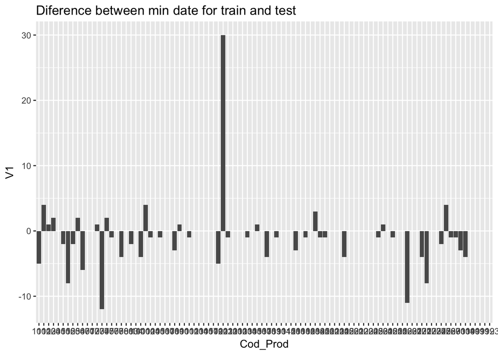

```r
#Hacemos un plot de la diferencia de periodos entre train y test (train - test)
ggplot(years.compared[,min_train-min_test,by =Cod_Prod], aes(x = Cod_Prod, y = V1)) + geom_bar(stat = 'identity') + ggtitle('Diference between min date for train and test')
```

*Hay productos que se venden mas en determinadas epocas del año?*

Mirando el efecto temporal, tambien es importante visualizar si hay productos que se tienden a comprar más en algunas épocas del año en concreto.

**Función para generar multiples plots**

```r
# Multiple plot function
#
# ggplot objects can be passed in ..., or to plotlist (as a list of ggplot objects)
# - cols:   Number of columns in layout
# - layout: A matrix specifying the layout. If present, 'cols' is ignored.
#
# If the layout is something like matrix(c(1,2,3,3), nrow=2, byrow=TRUE),
# then plot 1 will go in the upper left, 2 will go in the upper right, and
# 3 will go all the way across the bottom.
#
multiplot <- function(..., plotlist=NULL, file, cols=1, layout=NULL) {
  library(grid)

  # Make a list from the ... arguments and plotlist
  plots <- c(list(...), plotlist)

  numPlots = length(plots)

  # If layout is NULL, then use 'cols' to determine layout
  if (is.null(layout)) {
    # Make the panel
    # ncol: Number of columns of plots
    # nrow: Number of rows needed, calculated from # of cols
    layout <- matrix(seq(1, cols * ceiling(numPlots/cols)),
                    ncol = cols, nrow = ceiling(numPlots/cols))
  }

 if (numPlots==1) {
    print(plots[[1]])

  } else {
    # Set up the page
    grid.newpage()
    pushViewport(viewport(layout = grid.layout(nrow(layout), ncol(layout))))

    # Make each plot, in the correct location
    for (i in 1:numPlots) {
      # Get the i,j matrix positions of the regions that contain this subplot
      matchidx <- as.data.frame(which(layout == i, arr.ind = TRUE))

      print(plots[[i]], vp = viewport(layout.pos.row = matchidx$row,
                                      layout.pos.col = matchidx$col))
    }
  }
}
```

Vamos a graficar la distribución por mes de unos cuantos productos:

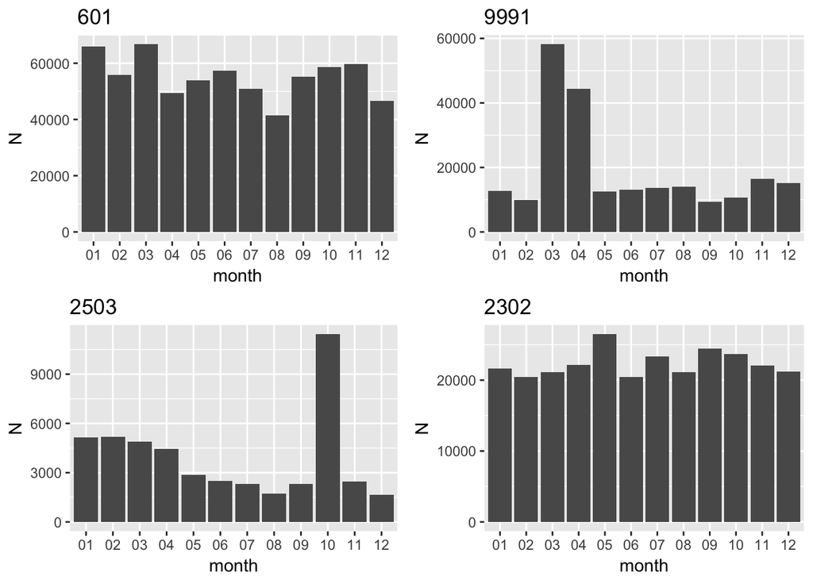

```r
unique_products <- data.train[,unique(Cod_Prod)]

#601: no hay un fecto de mes concreto
p1<- ggplot(data.train[Cod_Prod == unique_products[1],.N,by = c('month')],aes(x = month, y = N)) + geom_bar(stat = 'identity') + ggtitle(unique_products[1])

#2501: se compra especialmente en octubre
p2 <- ggplot(data.train[Cod_Prod == unique_products[4],.N,by = c('month')],aes(x = month, y = N)) + geom_bar(stat = 'identity') + ggtitle(unique_products[4])

#9991: se compra especialmente en marzo y abril
p3 <- ggplot(data.train[Cod_Prod == unique_products[13],.N,by = c('month')],aes(x = month, y = N)) + geom_bar(stat = 'identity') + ggtitle(unique_products[13])

#9993: se compra especialmente en marzo y abril
p4 <- ggplot(data.train[Cod_Prod == unique_products[14],.N,by = c('month')],aes(x = month, y = N)) + geom_bar(stat = 'identity') + ggtitle(unique_products[14])

multiplot(p1,p2,p3,p4, cols=2)
```

Se puede observar que sí que hay productos que se venden en épocas determinadas. Puede ser interesante añadir esta información en los modelos.

*Hay productos que se vendan juntos?* Otra idea interesante a explorar es identificar si hay algunos productos que se vendan juntos.

```r
#Cod_Prod a factor
data.train[,Cod_Prod := as.factor(Cod_Prod)]

#Número de comprar de cada producto por año
product.by.year<-data.train[,.N,by=c('Cod_Prod','year')][order(-N)]
```

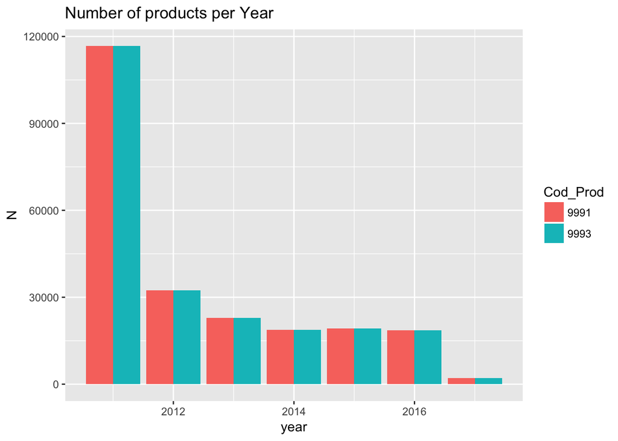

```r
# Que pasa con los productos 9993 y 9991?
ggplot(data.train[,.N,by = c('Cod_Prod','year')][Cod_Prod==9993 | Cod_Prod==9991], aes(x = year, y = N, fill = Cod_Prod)) + geom_bar(stat = 'identity', position = 'dodge')+ ggtitle('Number of products per Year')
```

Con este análisis hemos podido detectar que hay dos productos, el 9993 y el 9991, que tienen cada año el mismo número de compras. Así pues, es indicado suponer que se deben vender juntos o de manera consecutiva. Así pues, si en el test hay usuarios que han comprado uno de los dos productos y no tienen el otro, se les puede recomendar.

** Variables relacionadas con el customer **

Ahora queremos ver como actua cada customer, por ejemplo, es un customer que compra mucho? Cuando es su primera compra, y la última? Y el tiempo medio entre compras? De esta manera podemos provar de caracterizar los customers. También separaremos las últimas compras de cada customer, ya que nos servirán para comprovar nuestros modelos.

```r
#definimos una fecha actual
data.train[,date_today := today()]
data.train[,diff_date_today := as.numeric(difftime(date_today,date,units = 'days'))]

## Separamos los últimos productos de cada customer del train
last.products <- data.train[order(date), .(Cod_Prod =Cod_Prod[.N]), by = ID_Customer]
setkey(last.products,ID_Customer,Cod_Prod)

## Nos quedamos con el data train sin los últimos productos
setkey(data.train, ID_Customer, Cod_Prod)

## Variables de tiempo
temps_var_per_customer <- data.train[order(date),.(
  total_productes_comprats = .N, #N productos comprados
  temps_desde_primera_compra = diff_date_today[1], # tiempo desde 1a compra
  temps_desde_darrera_compra = diff_date_today[.N] #tiempo desde última compra compra
), by = ID_Customer]

data.train[,date := as.Date(date)]
data.train  <- data.train[order(date)]
#tiempo entre compras
lag_entre_compres <- data.train[, .(mean(as.numeric(diff.POSIXt(date)))), by = ID_Customer]

#Los customers que solo tienen un producto anterior tienen un lag de NAN
lag_entre_compres[is.nan(V1), V1 := NA]
setnames(lag_entre_compres,'V1','lag_entre_compres')
setkey(lag_entre_compres,ID_Customer)
setkey(temps_var_per_customer, ID_Customer)
temps_var_per_customer <-  temps_var_per_customer[lag_entre_compres,on = 'ID_Customer']

## Añadir temp_var_per_customer (variables temporales) al data.train.without.last
setkey(data.train, ID_Customer)
data.train<- data.train[temps_var_per_customer, on = 'ID_Customer']
```

Una vez preparadas las nuevas variables, vamos a graficar los resultados.

*Cuantos productos han comprado los customers?*

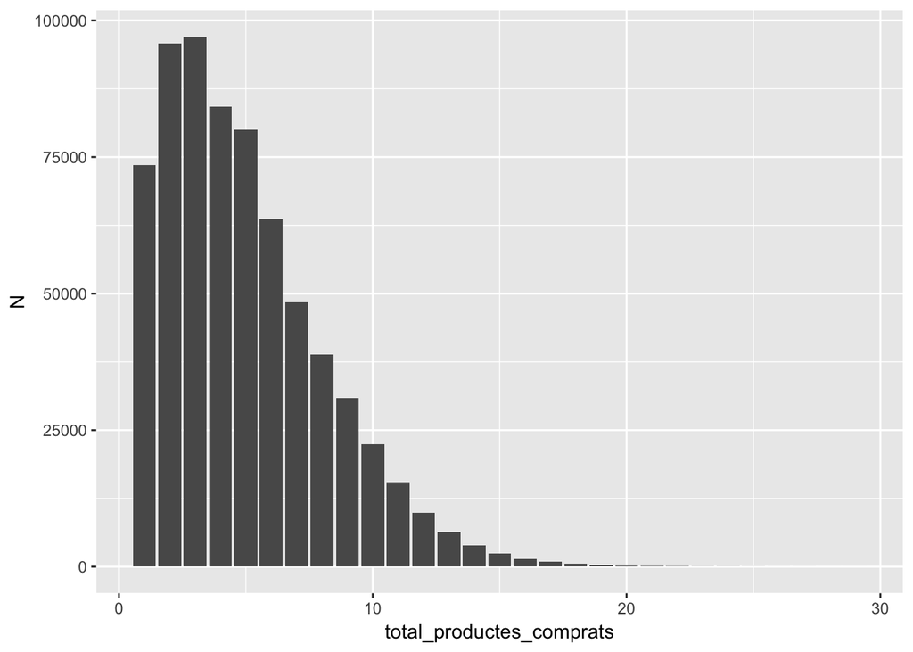

```r
## Graficamos
ggplot(temps_var_per_customer[,.N,by=total_productes_comprats], aes(x = total_productes_comprats, y = N)) + geom_bar(stat = 'identity')
```

Y de los que solo han comprado un producto, que productos predominan?

```r
## Customers solo con un producto
data.train[,Cod_Prod := as.factor(Cod_Prod)]
data.train[,Cod_Prod := as.factor(Cod_Prod)]
```

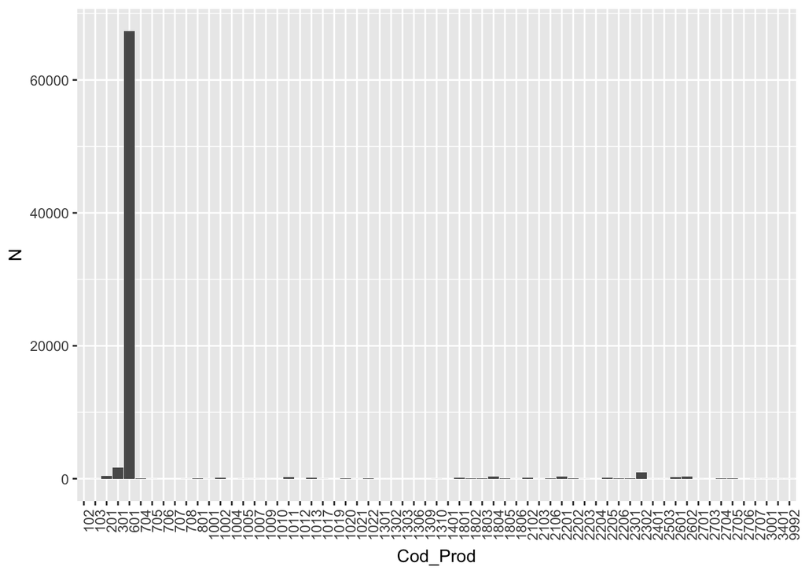

```r
ggplot(data.train[ID_Customer %in% temps_var_per_customer[is.na(lag_entre_compres), ID_Customer], .N,by = Cod_Prod], aes(x = Cod_Prod, y = N)) + geom_bar(stat = 'identity') + theme(axis.text.x = element_text(angle = 90, hjust = 1))
```

Se puede ver pues que el *601* destaca en esos usuarios que solo han comprado uno, y ya con menos productos, el *301*, el *201* y el *2302*.

Tambien se pueden evaluar los productos comprados por customers que compran mucho (> 10 productos).

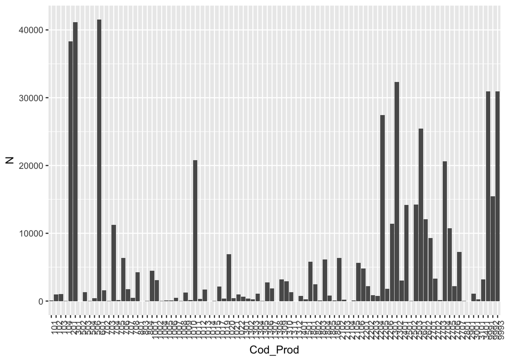

```r
## Customers con > 10 productos
ggplot(data.train[ID_Customer %in% temps_var_per_customer[total_productes_comprats > 10, ID_Customer],.N,by = Cod_Prod][order(-N)], aes(x = Cod_Prod, y = N)) + geom_bar(stat = 'identity') + theme(axis.text.x = element_text(angle = 90, hjust = 1))
```

El producto *601* sigue siendo muy alto, pero a él se unen también otros productos como el *201* y el *301*, el *2302* y la pareja formada por el *9991* y *9993*.

Y de los productos que se compran juntos (lag=0), que parejas predominan?

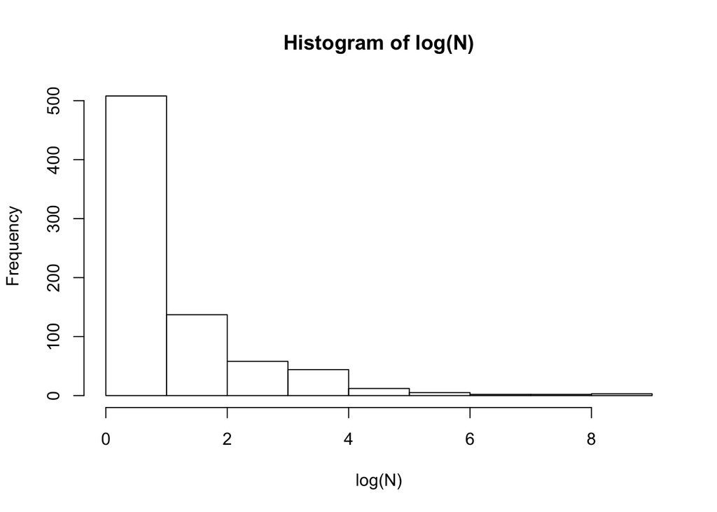

```r
## Customers with lag = 0
data.train[lag_entre_compres == 0, uniqueN(ID_Customer)]
data.train[lag_entre_compres == 0, .N]
data.train[lag_entre_compres == 0, .N, by = ID_Customer][,table(N)]
groups_of_products <- data.train[lag_entre_compres == 0,paste0(Cod_Prod,collapse = '-'), by = ID_Customer]
groups_of_products[,.N,by = V1][order(-N)]
groups_of_products[,.N,by = V1][,hist(log(N))]
```

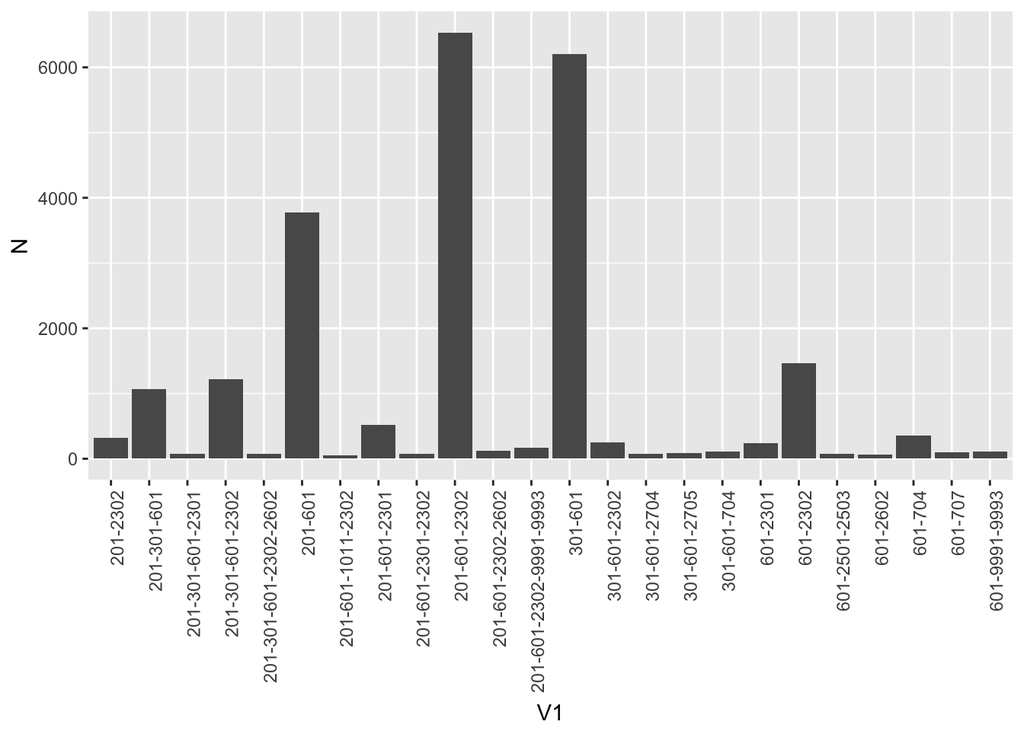

```r
ggplot(groups_of_products[,.N,by = V1][log(N) > 4], aes(x = V1, y = N)) + geom_bar(stat = 'identity') + theme(axis.text.x = element_text(angle = 90, hjust = 1))
```

Por otra parte, es de esperar que haya customers que tiendan a comprar más en unos meses que en otros, así que también es interesante mirar si hay este efecto.

```r
## Compras de mes por customer
compres.per.customer.per.mes <- data.train[,.N,by = c('ID_Customer','month')]
compres.per.customer.dcast <- dcast.data.table(compres.per.customer.per.mes, ID_Customer ~ month, value.var = 'N')
setnames(compres.per.customer.dcast,grep('[0-9]',colnames(compres.per.customer.dcast),value = T), paste0('month_', grep('[0-9]',colnames(compres.per.customer.dcast),value = T)))
compres.per.customer.dcast[is.na(compres.per.customer.dcast)] <- 0

setkey(temps_var_per_customer,ID_Customer)
setkey(compres.per.customer.dcast,ID_Customer)
temps_var_per_customer <- temps_var_per_customer[compres.per.customer.dcast]
```

Vamos a graficar algunos customers para ver su comportamiento:

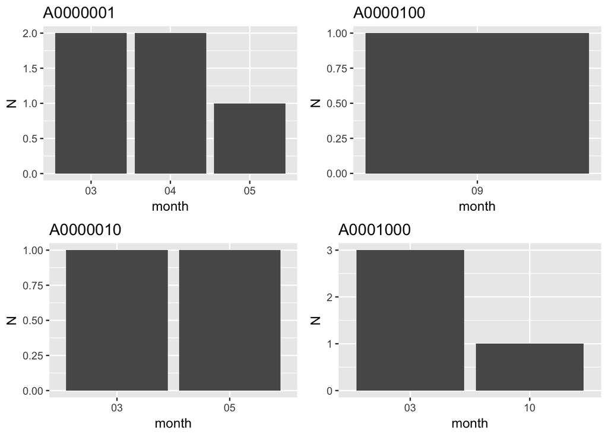

```r
unique_customers <- data.train[,unique(ID_Customer)]

#A0000001: compra en marzo, abril y mayo
p1<- ggplot(data.train[ID_Customer == unique_customers[1],.N,by = c('month')],aes(x = month, y = N)) + geom_bar(stat = 'identity') + ggtitle(unique_customers[1])

#A0000010: compra en marzo y abril
p2<- ggplot(data.train[ID_Customer == unique_customers[10],.N,by = c('month')],aes(x = month, y = N)) + geom_bar(stat = 'identity') + ggtitle(unique_customers[10])

#A0000100: compra un producto en setiembre
p3<- ggplot(data.train[ID_Customer == unique_customers[100],.N,by = c('month')],aes(x = month, y = N)) + geom_bar(stat = 'identity') + ggtitle(unique_customers[100])

#A0001000: compra en marzo y octubre
p4<- ggplot(data.train[ID_Customer == unique_customers[1000],.N,by = c('month')],aes(x = month, y = N)) + geom_bar(stat = 'identity') + ggtitle(unique_customers[1000])

multiplot(p1,p2,p3,p4, cols=2)
```

Por otro lado, fijandonos en el tiempo de compras, podemos generar los siguientes gráficos:

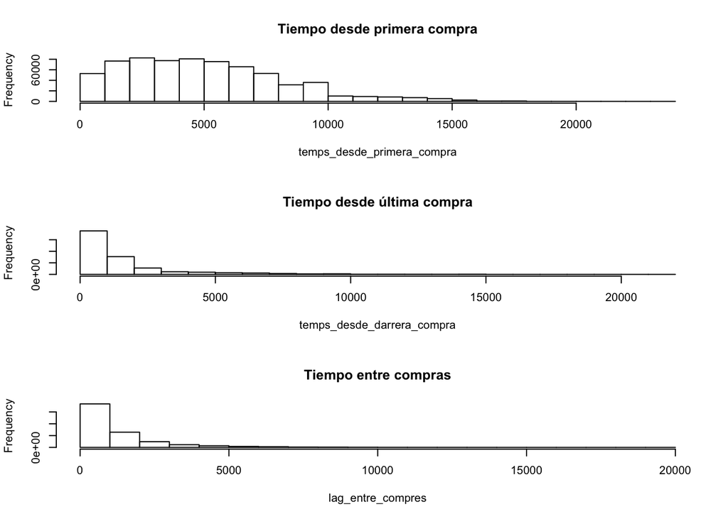

```r
par(mfrow=c(3,1))
p1<- temps_var_per_customer[,hist(temps_desde_primera_compra, main='Tiempo desde primera compra')]
p2 <- temps_var_per_customer[,hist(temps_desde_darrera_compra, main='Tiempo desde última compra')]
p3 <- temps_var_per_customer[,hist(lag_entre_compres,main='Tiempo entre compras')]
```

```r
summary(temps_var_per_customer$temps_desde_primera_compra)
summary(temps_var_per_customer$temps_desde_darrera_compra)
summary(temps_var_per_customer$lag_entre_compres)
```

*Relación entre último y penúltimo producto*

Otra idea interesante es mirar la relación entre un producto y el anterior comprado, es decir, si después de comprar uno se tiende a comprar otro en concreto. Para mirar esta idea se cogen los últimos y penúltimos productos de cada customer, para ver que parejas de productos se compran más seguidas.

```r
## Separamos los últimos productos de cada customer del train
last.products <- data.train[order(date), .(Cod_Prod =Cod_Prod[.N]), by = ID_Customer]
setkey(last.products,ID_Customer,Cod_Prod)

## Nos quedamos con el data train sin los últimos productos
setkey(data.train, ID_Customer, Cod_Prod)
data.train.without.last <- data.train[!last.products, ]

## cogemos los penúltimos productos
penultim.products <- data.train.without.last[order(date), .(Cod_Prod =Cod_Prod[.N]), by = ID_Customer]
setnames(penultim.products,'Cod_Prod','penultim_cod_prod')
setnames(last.products,'Cod_Prod','last_cod_prod')
setkey(penultim.products, ID_Customer)
setkey(last.products, ID_Customer)

#ultimos vs penúltimos
last.vs.penultim <- last.products[penultim.products]

last.vs.penultim.product.table <- as.data.table(last.vs.penultim[,(table(last_cod_prod,penultim_cod_prod))])
last.vs.penultim.product.table[,logN := log(N)]
```

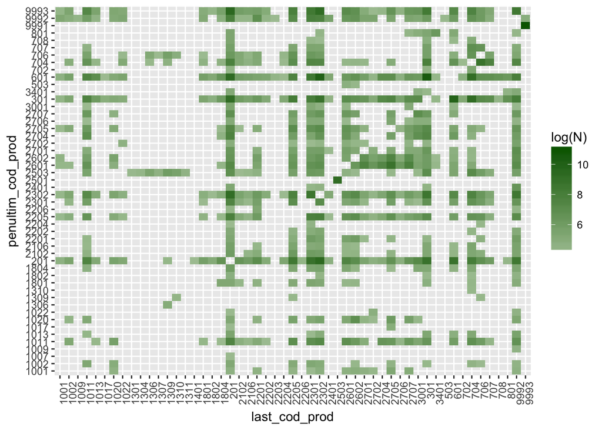

```r
# Matriz de N último vs penútimo en escala logarítmica
ggplot(data = last.vs.penultim.product.table[logN >4], aes(x = last_cod_prod, y = penultim_cod_prod)) + geom_tile(aes(fill = log(N)))  + scale_fill_gradient2(low="darkblue", high="darkgreen", guide="colorbar") + theme(axis.text.x = element_text(angle = 90, hjust = 1))
```

Hay algunos productos que se compran bastante seguidos, como por ejemplo el *9991* y el *9993*, como ya hemos comentado anteriormente, el *601* y el *301*, y también el *601* y el *2302*, entre otros. Estos productos han estado apareciendo en todos los análisis hechos hasta ahora, lo que indica que deben ser productos que compran todo tipo de clientes y deben ser bastante básicos. Además, esta matriz nos puede dar una idea de relaciones entre productos, y también nos plantea la posiblidad de hacer cluster de productos para detectar este tipo de relaciones.